# Time series: identifying frequencies

Here are two links that try to explain the fourier transform:

- https://betterexplained.com/articles/an-interactive-guide-to-the-fourier-transform/
- http://toxicdump.org/stuff/FourierToy.swf

### The Fourier transform

The [Fourier transform](https://en.wikipedia.org/wiki/Fourier_series) decomposes any signal into the weighted sum of a number of sin and cos functions with different frequency:

$$s_N(t) = a_0/2 + \sum_{n=1}^{N} \big( a_n \cos(\frac{2\pi n t}{P}) + b_n sin(\frac{2\pi n t}{P}) \big)$$

with $P$ the period (frequency $1/P$), and $N$ the length of the series. The Fourier transform, or spectrum, or periodogram, depicts amplitude against frequency.

### artificial data:

pure sinus data, unsmoothed (raw) spectrum:

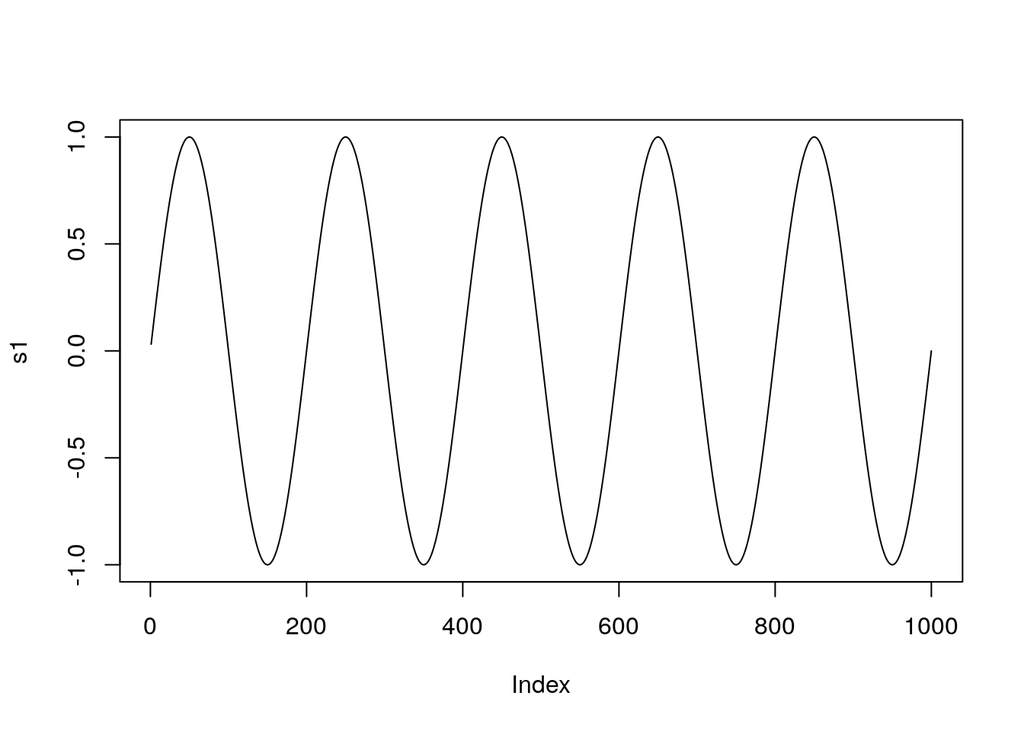

```r
n = 1000
x = pi * 1:n
s1 = sin(x / 100)
plot(s1, type = 'l')
```

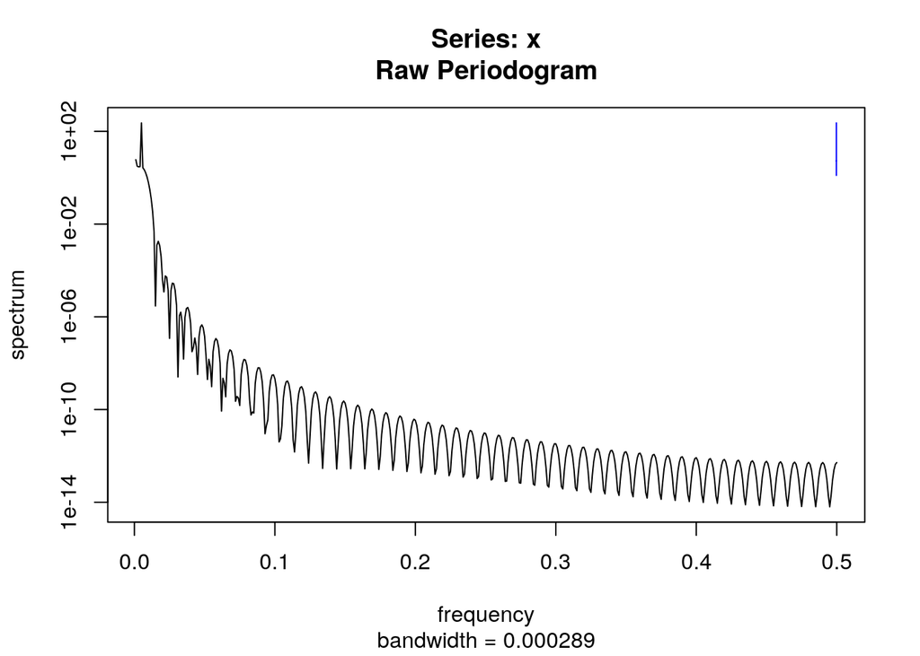

```r
plot(spectrum(s1))
```

smoothed spectrum:

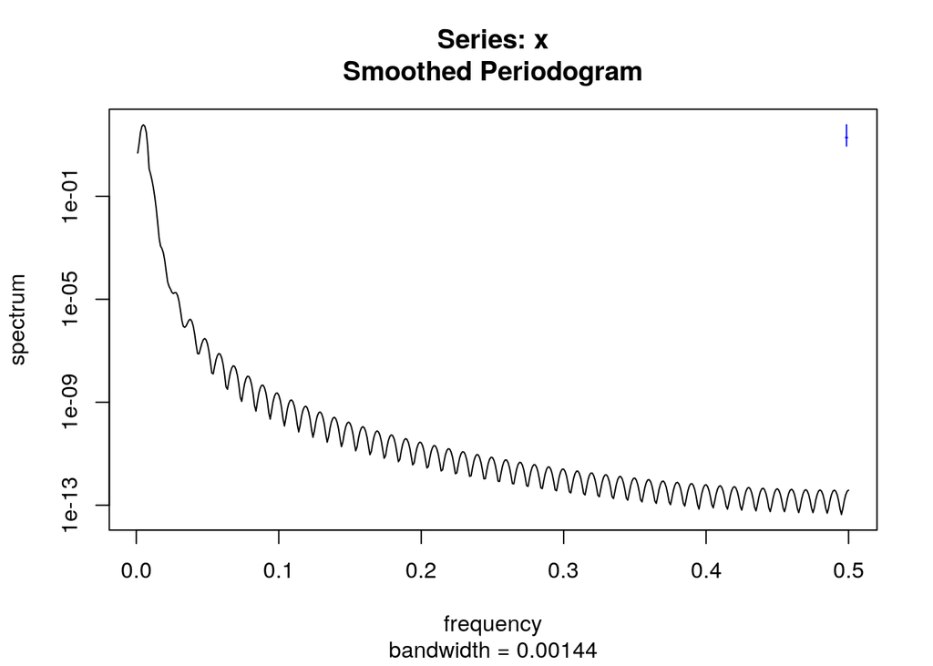

```r
plot(spectrum(s1, spans = c(3,5)))
```

higher frequency sinus:

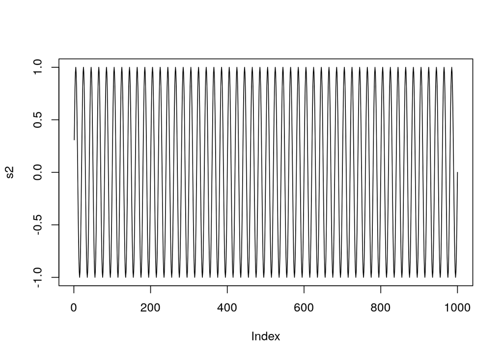

```r
s2 = sin(x / 10)
plot(s2, type = 'l')
```

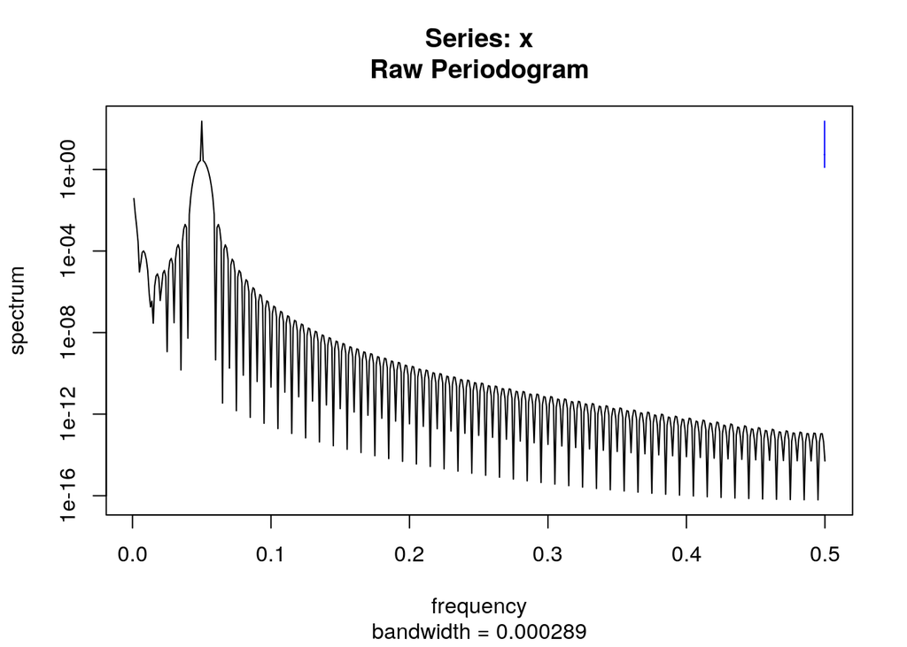

```r
plot(spectrum(s2))
```

smoothed curve:

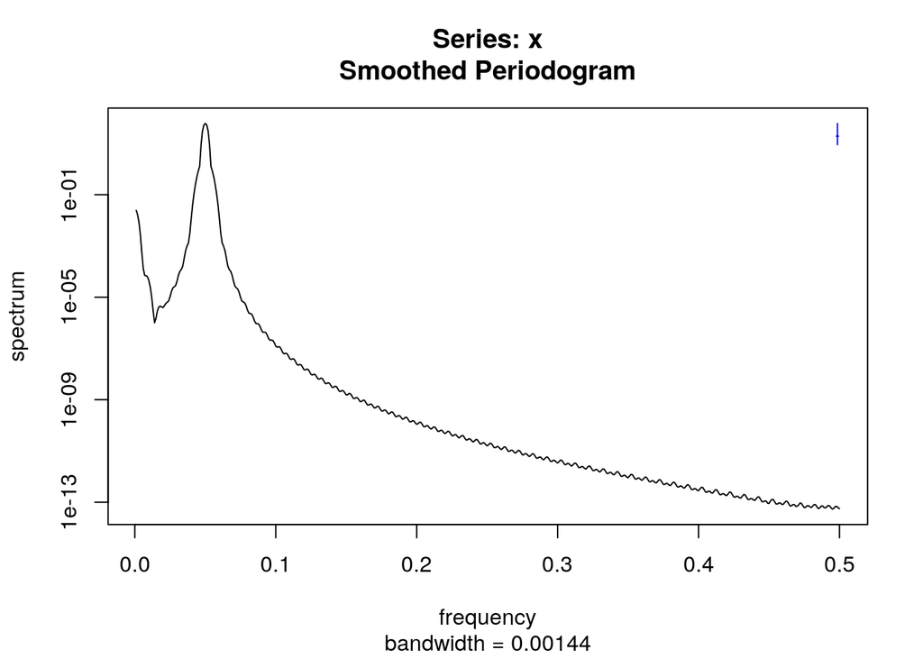

```r
plot(spectrum(s2, spans = c(3,5)))
```

superposition of both:

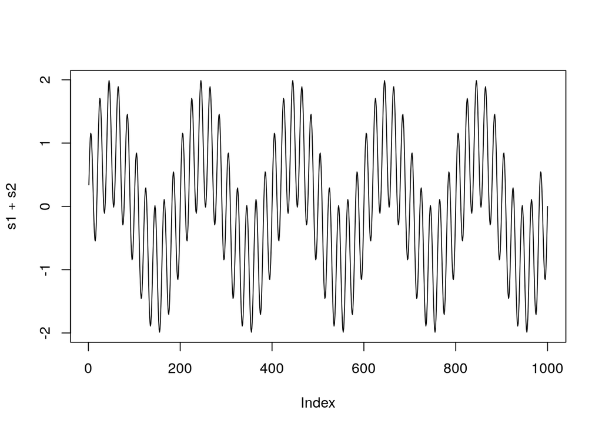

```r
plot(s1+s2, type = 'l')
```

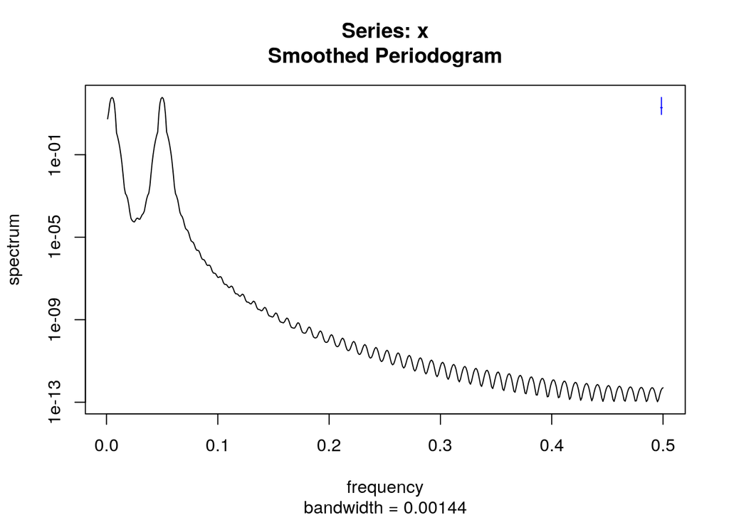

```r
plot(spectrum(s1+s2, spans = c(3,5)))
```

adding noise to them

```
ns = s1 + s2 + rnorm(n)
plot(ns, type = 'b')
plot(spectrum(ns))
```

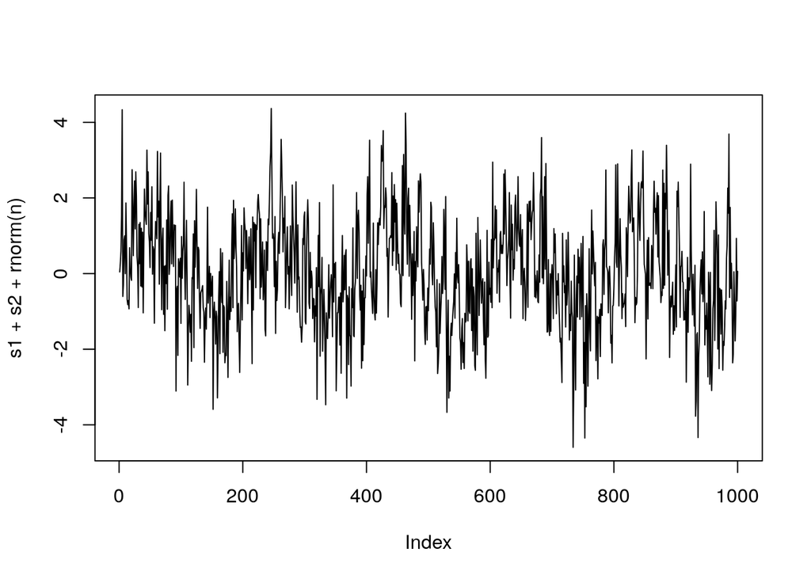

```r
plot(s1+s2+rnorm(n), type = 'l')
```

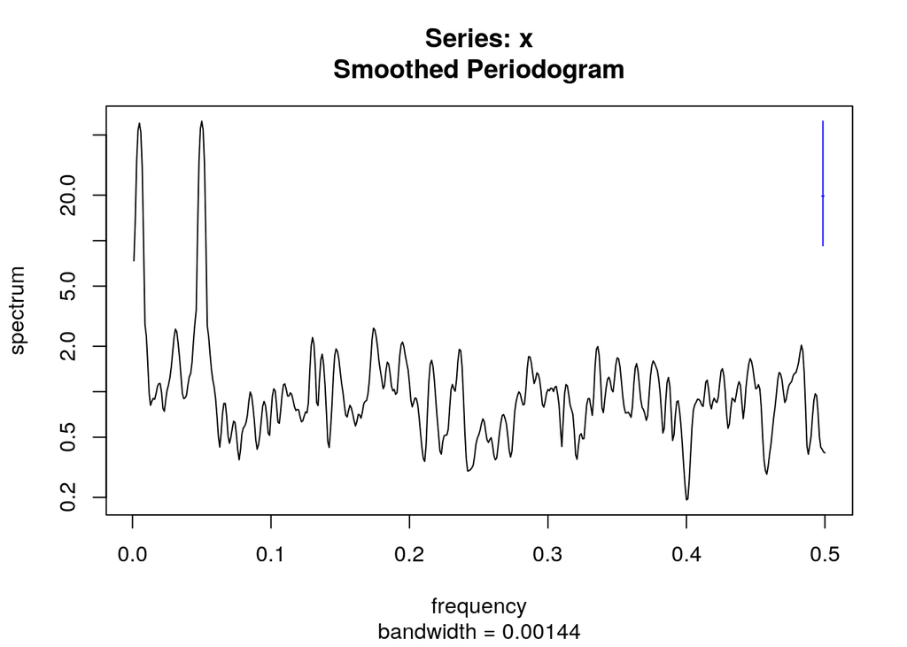

```r
plot(spectrum(s1+s2+rnorm(n), spans = c(3,5)))
```

### stl components of co2:

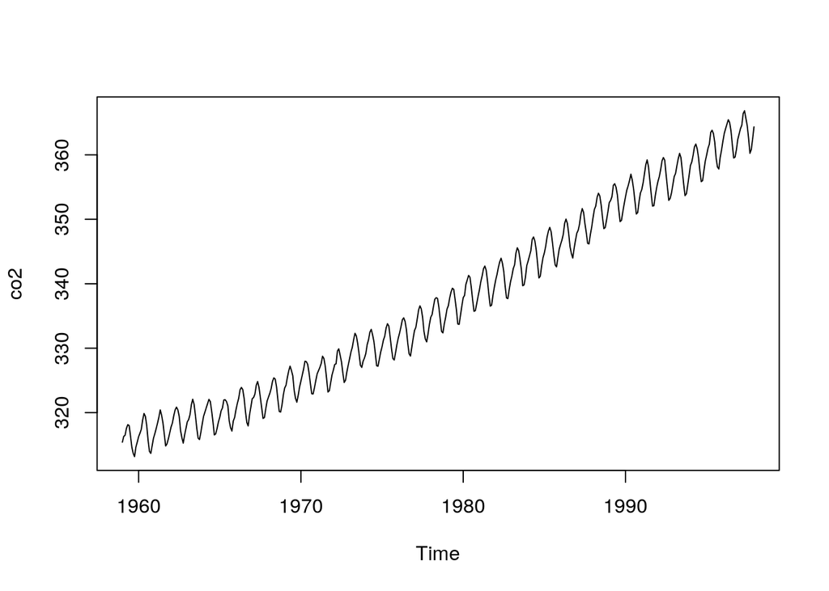

```r
plot(co2)
```

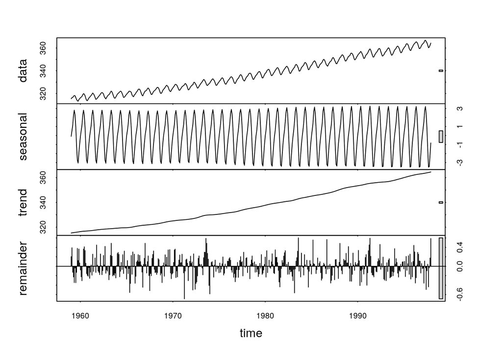

```r
s = stl(co2, 12)
plot(s)
```

```r
s$time.series[1:10,]
```

```
##          seasonal    trend   remainder
##  [1,] -0.08566422 315.3017  0.20396197
##  [2,]  0.52639420 315.3919  0.39170128
##  [3,]  1.14390881 315.4821 -0.12601561
##  [4,]  2.21382011 315.5723 -0.22612919
##  [5,]  2.81338319 315.6621 -0.34543510
##  [6,]  2.28378607 315.7518 -0.03558082
##  [7,]  0.89582997 315.8415 -0.34736755
##  [8,] -1.15165133 315.9305 -0.12886241
##  [9,] -2.71719702 316.0195  0.37770712
## [10,] -3.04835079 316.1085  0.11988472
```

fetching the seasonal component:

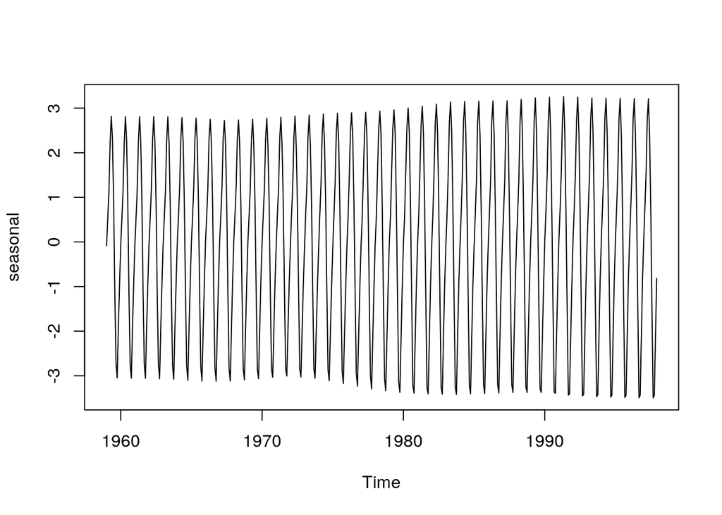

```r
seasonal = s$time.series[,1]
plot(seasonal)
```

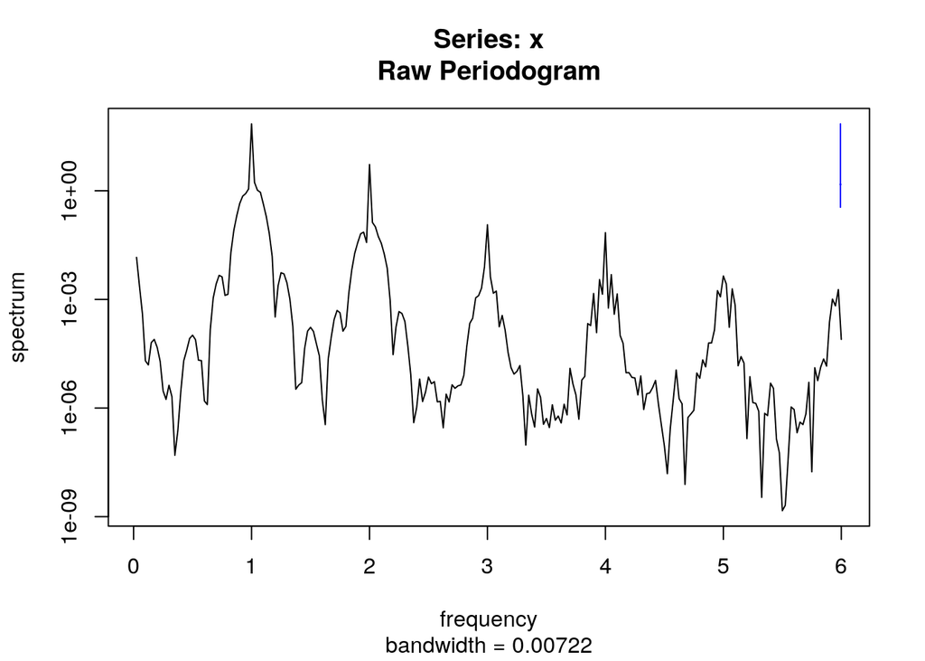

```r
plot(spectrum(seasonal))
```

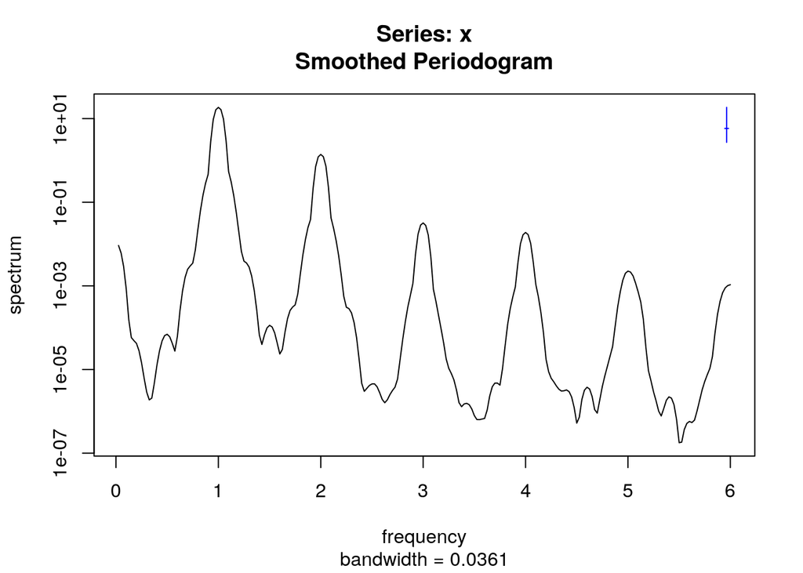

```r
plot(spectrum(seasonal, spans = c(3,5)))
```

fetching the trend component:

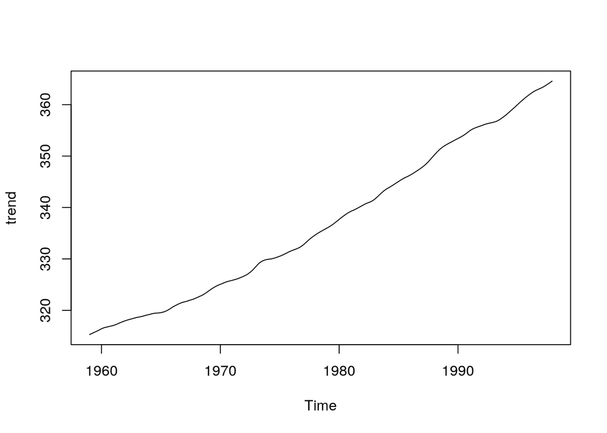

```r
trend = s$time.series[,2]
plot(trend)
```

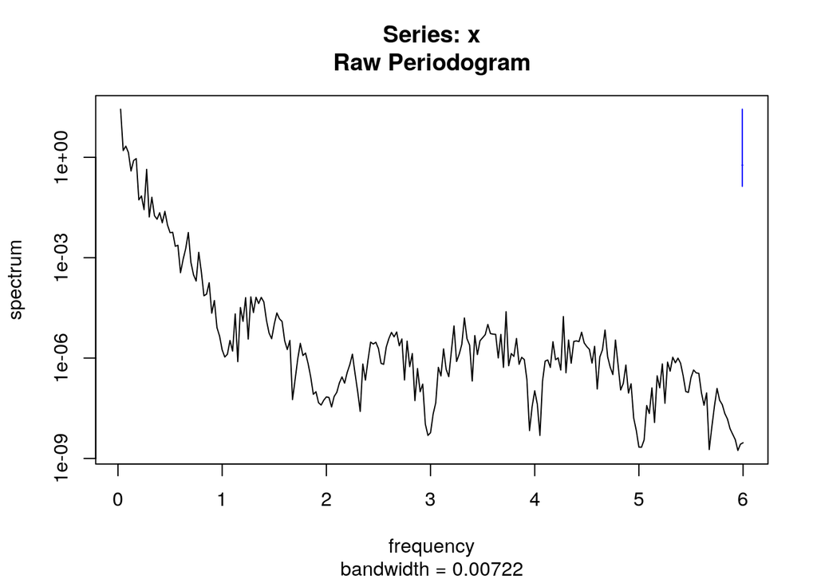

```r
plot(spectrum(trend))
```

fetching the remainder:

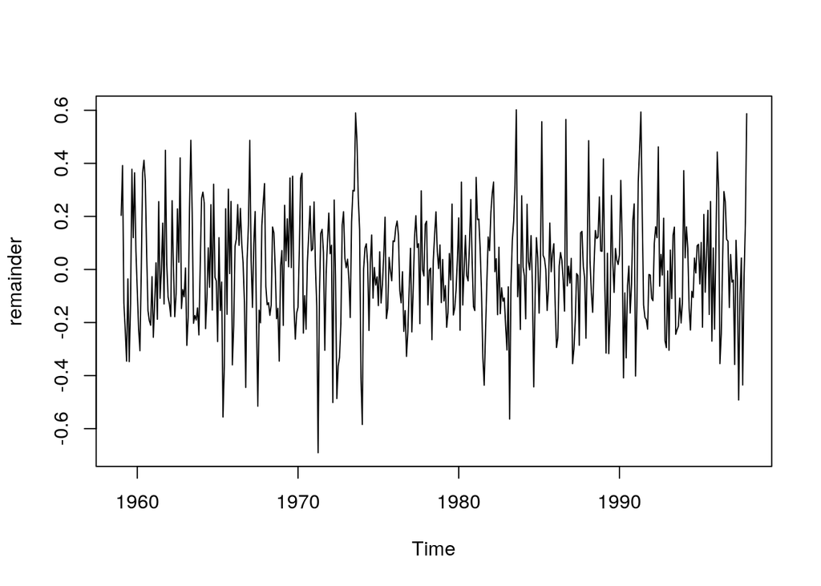

```r
remainder = s$time.series[,3]
plot(remainder)
```

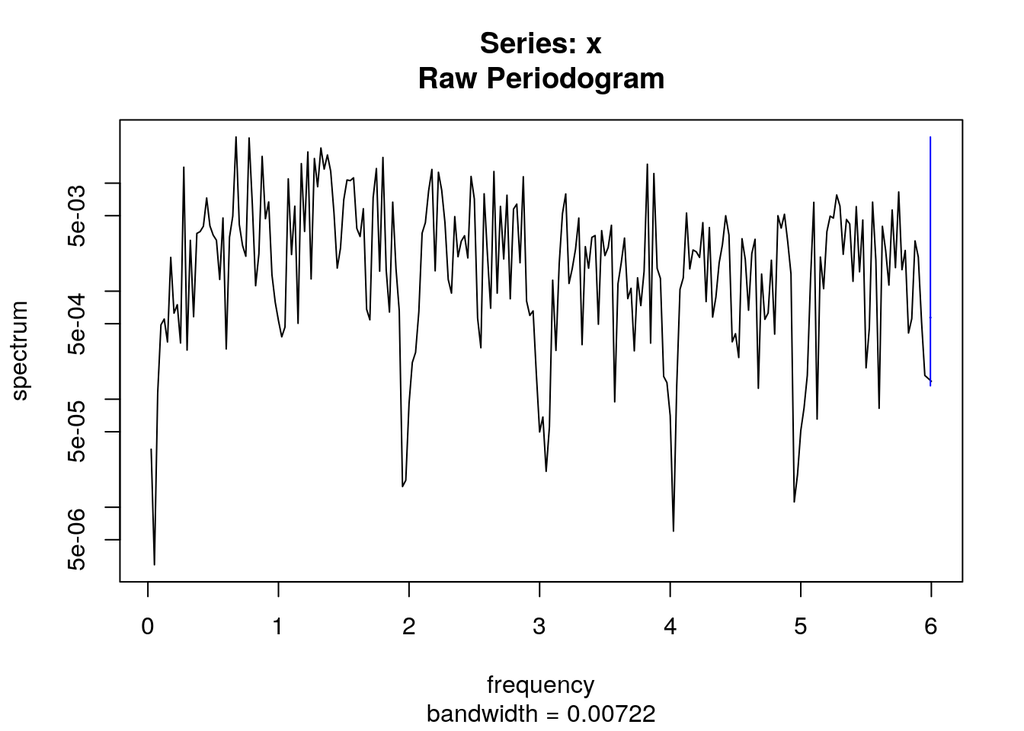

```r
plot(spectrum(remainder))
```

## Exercises

E1. Generate a saw pattern, e.g. by

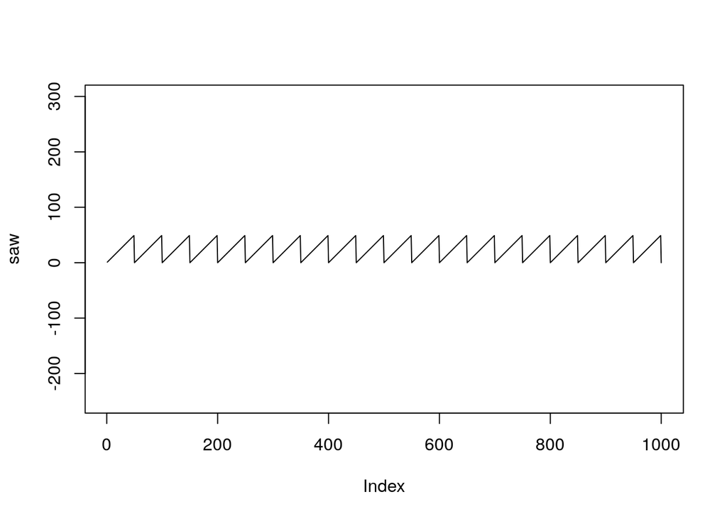

```r
saw = 1:1000 %% 50
plot(saw, type = 'l', asp = 1)
```

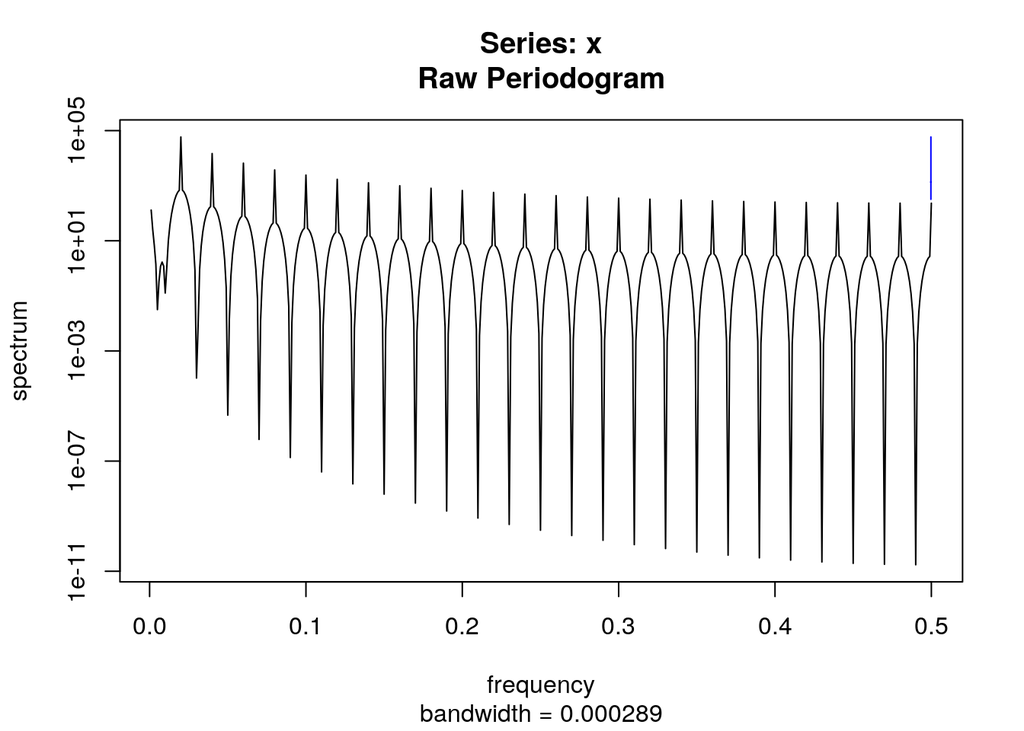

```r
saw.ts = ts(saw, frequency = 50)
spectrum(saw)
```

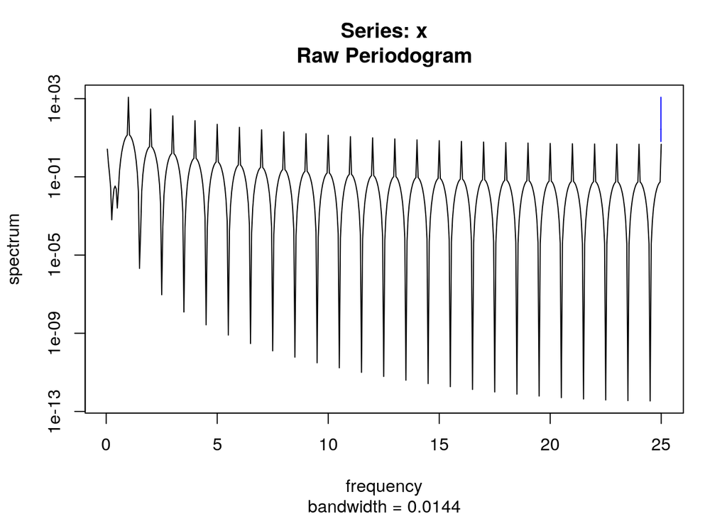

```r
spectrum(saw.ts)
```

```r
# what we see is called harmonics
s = stl(co2, s.window = 12)
sp = spectrum(s$time.series[,"seasonal"])
```

[figure not shown]

- compute and plot a spectrum of this series
- describe and explain what you see
- compare this to what you saw in the spectrum of the periodic component of the `co2` dataset

E2. In the PM10 data we looked at last week (`data(air, package = "spacetime")`), investigate whether there is a weekly, monthly or yearly cyclic trend present in the time series for the first station.

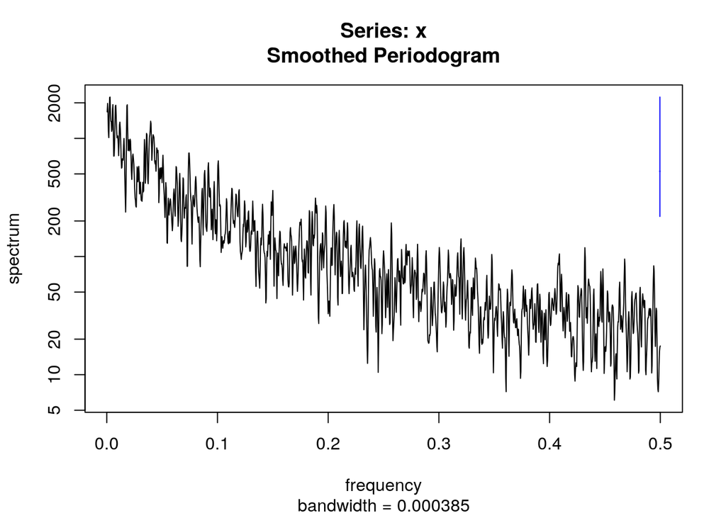

```r
data(air, package = "spacetime")
station1 = air[1,]
station1.clean = zoo::na.approx(station1)
spectrum(station1.clean, spans = c(3,3))
```

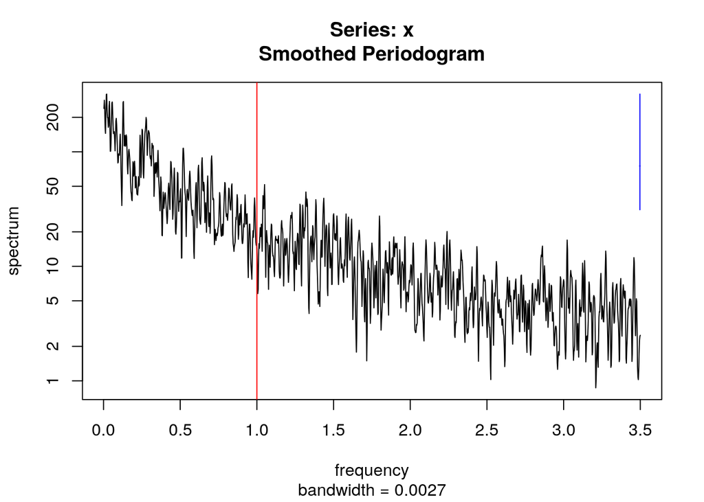

```r
spectrum(ts(station1.clean, frequency = 7), spans = c(3,3))
abline(v = 1, col = 'red')
```

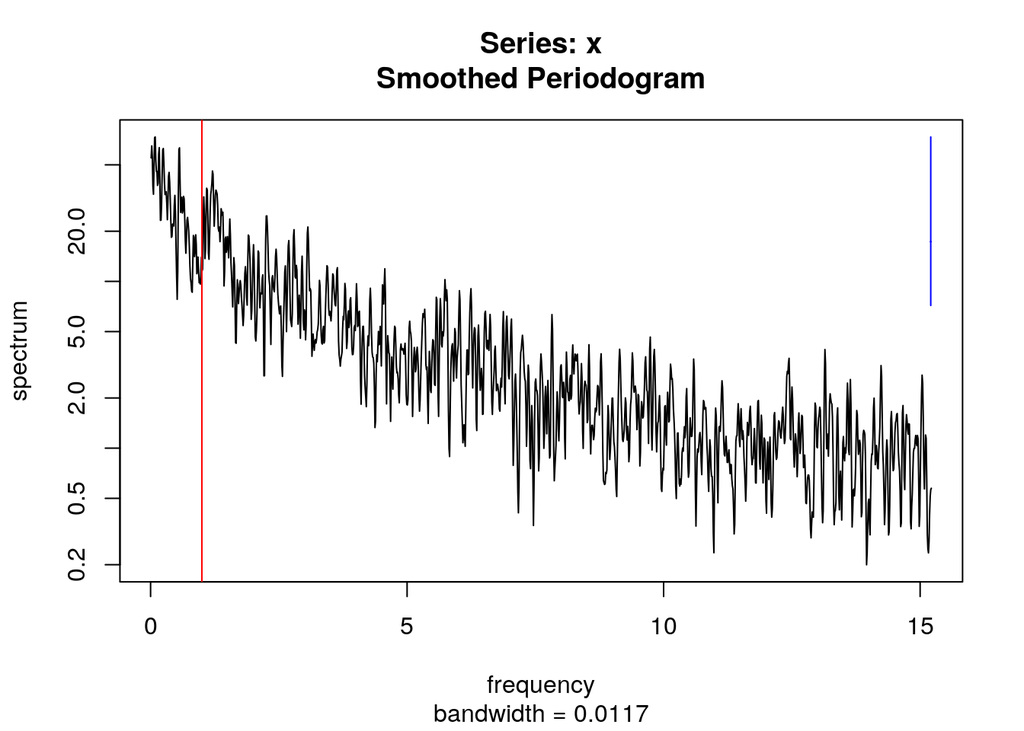

```r
spectrum(ts(station1.clean, frequency = 365.25/12), spans = c(3,3))
abline(v = 1, col = 'red')
```

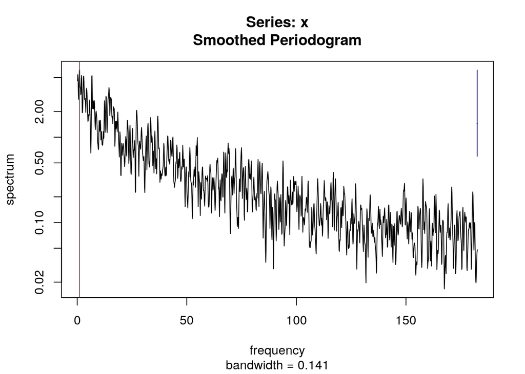

```r
spectrum(ts(station1.clean, frequency = 365.25), spans = c(3,3))
abline(v = 1, col = 'red')
```

E3. From http://pebesma.staff.ifgi.de/pm10/ download the first dataset, and import it in R. Examine the spectrum, autocorrelation function and partial autocorrelation function of the PM10 variable measured. Is this a regular time series?

```r
pm10 = read.csv("http://pebesma.staff.ifgi.de/pm10/3_1a.txt")
head(pm10)
```

```
##        Lat     Long         Time       Date  pm10  TimeTotal
## 1 51.95290 7.632011 18:25:17.000 2010/03/22 0.118 3626709917
## 2 51.95325 7.631870 18:25:18.000 2010/03/22 0.123 3626709918
## 3 51.95335 7.631814 18:25:19.000 2010/03/22 0.128 3626709919
## 4 51.95347 7.631763 18:25:20.000 2010/03/22 0.128 3626709920
## 5 51.95356 7.631695 18:25:21.000 2010/03/22 0.124 3626709921
## 6 51.95361 7.631666 18:25:22.000 2010/03/22 0.126 3626709922
```

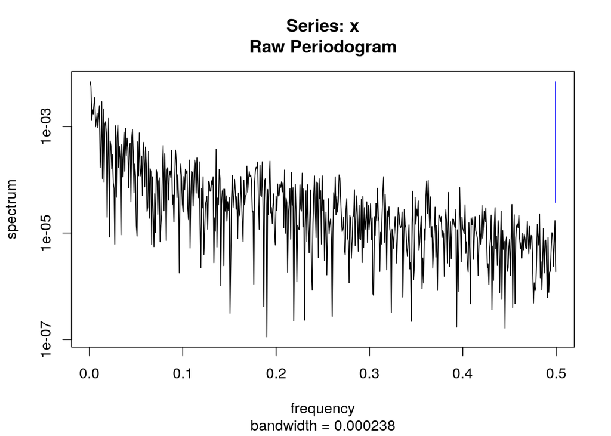

```r
spectrum(pm10$pm10)
```

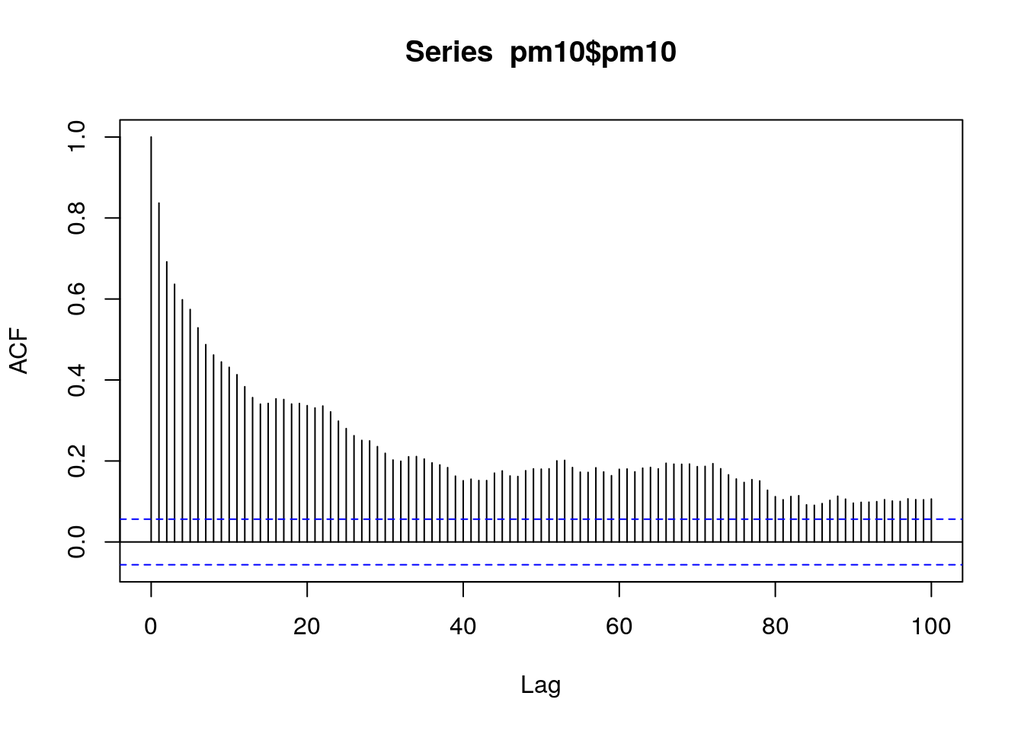

```r
acf(pm10$pm10, 100)
```

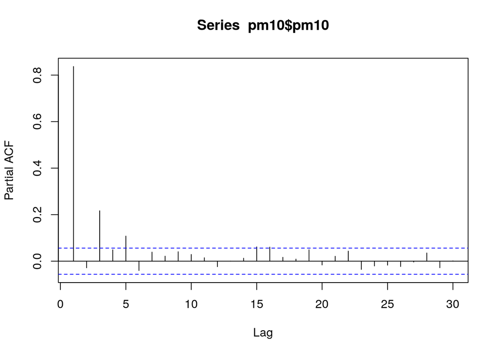

```r
pacf(pm10$pm10)
```

```r
pm10$tm = as.POSIXct(strptime(paste(as.character(pm10$Date), as.character(pm10$Time)), "%Y/%m/%d %H:%M:%OS"))
head(pm10)
```

```
##        Lat     Long         Time       Date  pm10  TimeTotal
## 1 51.95290 7.632011 18:25:17.000 2010/03/22 0.118 3626709917
## 2 51.95325 7.631870 18:25:18.000 2010/03/22 0.123 3626709918
## 3 51.95335 7.631814 18:25:19.000 2010/03/22 0.128 3626709919
## 4 51.95347 7.631763 18:25:20.000 2010/03/22 0.128 3626709920
## 5 51.95356 7.631695 18:25:21.000 2010/03/22 0.124 3626709921
## 6 51.95361 7.631666 18:25:22.000 2010/03/22 0.126 3626709922
##                    tm
## 1 2010-03-22 18:25:17
## 2 2010-03-22 18:25:18
## 3 2010-03-22 18:25:19
## 4 2010-03-22 18:25:20
## 5 2010-03-22 18:25:21
## 6 2010-03-22 18:25:22
```

```r
table(diff(pm10$tm))
```

```
##
##    1    2    3    4    5    6    9   12   17   98 6666
## 1171   12    9    4    3    5    1    2    1    1    1
```